# Multi-condition single-cell RNA-seq analysis with LEMUR

## Harmony

Harmony is a popular tool for data integration (Korsunsky et al. 2019). It is relatively fast and can handle more complex experimental designs than just a treatment/control setup. It is built around *maximum diversity clustering* (Figure 23). Like many clustering algorithms, maximum diversity clustering aims to minimize the distance of each data point to its respective cluster center, and in addition it also aims to maximize the mixing of conditions (or “batches”) assigned to each cluster.

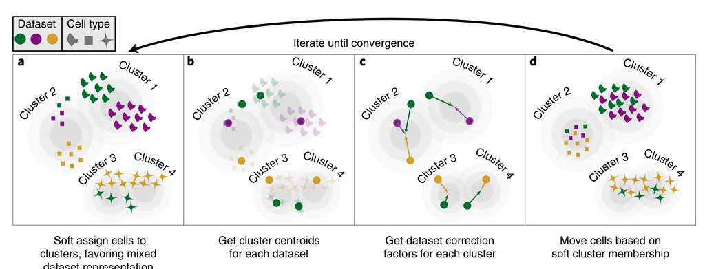

Figure 23: Schematic of Harmony. Screenshot from Fig. 1 of Korsunsky et al. (2019)

```
Initializing centroids
```

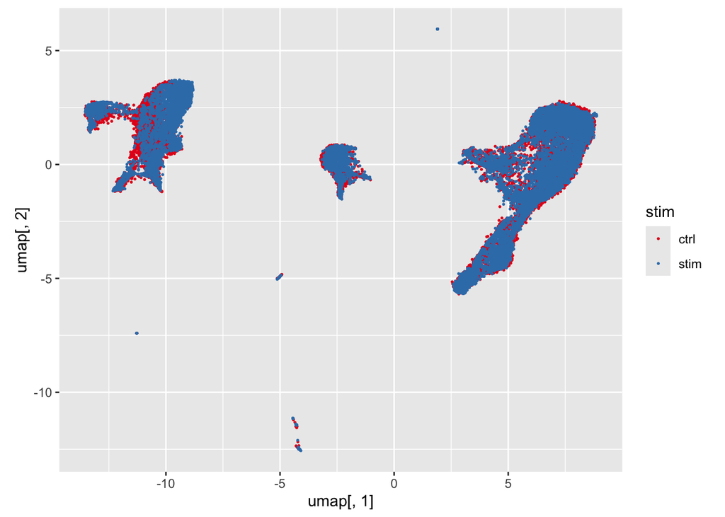

```r
harm_umap <- uwot::umap(harm_mat)

as_tibble(colData(sce)) |>
  mutate(umap = harm_umap) |>
  ggplot(aes(x = umap[, 1], y = umap[, 2])) +
    geom_point(aes(colour = stim), size = 0.3) +
    coord_fixed()
```

**NoteChallenge: How do you do integration in Seurat?**

The integration method of Seurat is based on mutual nearest neighbours (MNN) by Haghverdi et al. (2018). However, Seurat calls the mutual nearest neighbours *integration anchors*. The main difference is that Seurat uses canonical correspondence analysis (CCA) instead of principal component analysis (PCA) for dimensionality reduction (Butler et al. 2018).

```r
# This code only works with Seurat v5!
seur_obj2 <- Seurat::as.Seurat(muscData::Kang18_8vs8(), data = NULL)
```

```
see ?muscData and browseVignettes('muscData') for documentation
```

```
loading from cache
```

```r
seur_obj2[["originalexp"]] <- split(seur_obj2[["originalexp"]], f = seur_obj2$stim)
seur_obj2 <- Seurat::NormalizeData(seur_obj2, normalization.method = "LogNormalize", scale.factor = 10000)
```

```
Normalizing layer: counts.ctrl
```

```
Normalizing layer: counts.stim
```

```r
seur_obj2 <- Seurat::FindVariableFeatures(seur_obj2, selection.method = "vst", nfeatures = 500)
```

```
Finding variable features for layer counts.ctrl
```

```
Finding variable features for layer counts.stim
```

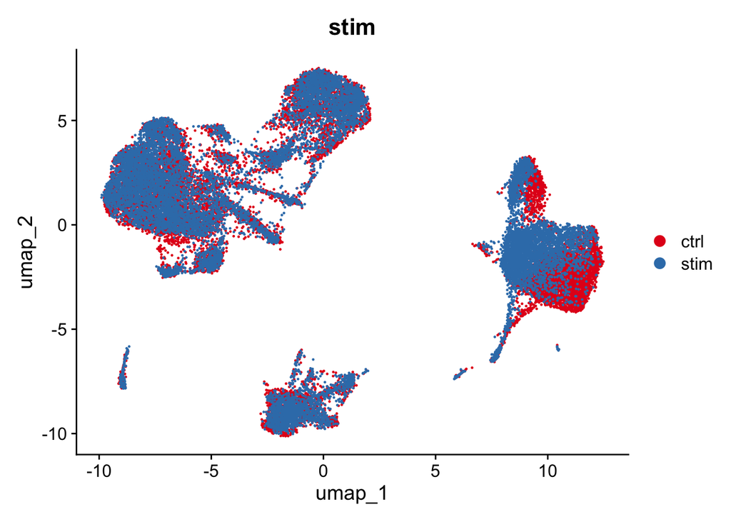

Figure 24: Seurat anchor integration

```r
seur_obj2 <- Seurat::ScaleData(seur_obj2)
seur_obj2 <- Seurat::RunPCA(seur_obj2, verbose = FALSE)

seur_obj2 <- Seurat::IntegrateLayers(object = seur_obj2, method = Seurat::CCAIntegration, orig.reduction = "pca", new.reduction = "integrated.cca", verbose = FALSE)
seur_obj2 <- Seurat::RunUMAP(seur_obj2, dims = 1:30, reduction = "integrated.cca")
Seurat::DimPlot(seur_obj2, reduction = "umap", group.by = "stim")
```

## Adjacency matrix

**NoteChallenge: Plotting the adjacency matrix**

Plot `adj_jn`, i.e., the matrix spanned by the `j`-th NMF components `adjnmf$h[j, ]` and `adjnmf$w[, j])`, as a heatmap similar to Figure 14.

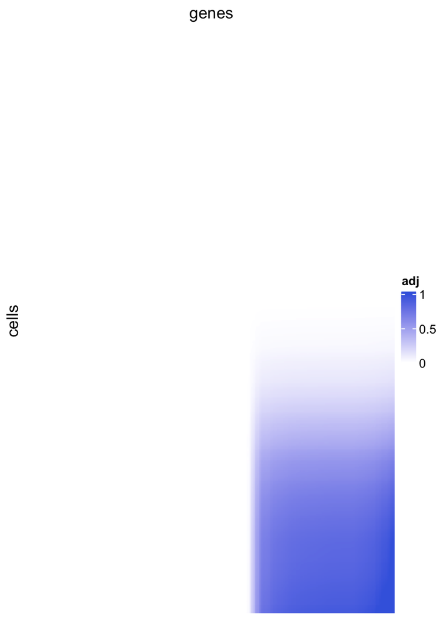

Figure 25: The matrix approximation from the j-th NMF component

```r
Heatmap(adj_jn[csub, ][order(adjnmf$w[csub, j]), order(adjnmf$h[j, ])],
  name = "adj", col = colorRamp2(c(0, 1), c("#ffffff", "RoyalBlue")),
  row_title = "cells", column_title = "genes", use_raster = TRUE,
  show_row_names = FALSE, show_column_names = FALSE, cluster_rows = FALSE, cluster_columns = FALSE
)
```

Note that here we use a [sequential colour map rather than a diverging](https://www.huber.embl.de/msmb/03-chap.html#sec-graphics-color) one, since the values are all positive. To order the rows and columns in this plot, we use the size of the NMF coefficients `w` and `h`. This is unlike in Figure 14, where we used, in lack of better alternatives, a dendrogram ordering[^4].

Similar plots can easily be produced for other values of `j`.

<sup>4</sup> See, e.g., https://jokergoo.github.io/ComplexHeatmap-reference/book/a-single-heatmap.html Section 2.3.4.

## Bicluster coverage

**NoteChallenge: Looking at the coverage of the biclusters**

Create a plot like Figure 25 for the linear combination of all 10 factors, i.e., visualize the low-rank (`k=`10) approximation and compare it to Figure 14.

```r
dichotomise <- function(x) {
  # `cluster` is either 1 or 2, `centers` are the coordinates of the cluster centers, the `sign` function returns values
  # of -1 or +1 depending on the relative position of the centers along the real axis. The expression below gives
  # `TRUE` if a point is in the cluster with the larger center, `FALSE` otherwise.
  with(kmeans(as.vector(x), centers = 2), 3 + sign(as.vector(diff(centers))) == 2 * cluster)
}

wd <- apply(adjnmf$w, 2, dichotomise)
hd <- apply(adjnmf$h, 1, dichotomise) |> t()

# We use this for visualization below.
adjappr     <- wd %*% hd

# We use this for seriation below. BEA_TSP seems to be sensitive to the absolute scale of the data (?), hence, the division of the geometric mean of d.
adjappr4ser <- wd %*% diag(adjnmf$d) %*% hd  / exp(mean(log(adjnmf$d)))

# Subsampling for visualisation
csub        <- sample(nrow(adj), 2048)
adjs        <- abs(adj[csub, ])
adjapprs    <- adjappr[csub, ]
adjappr4ser <- adjappr4ser[csub, ]
```

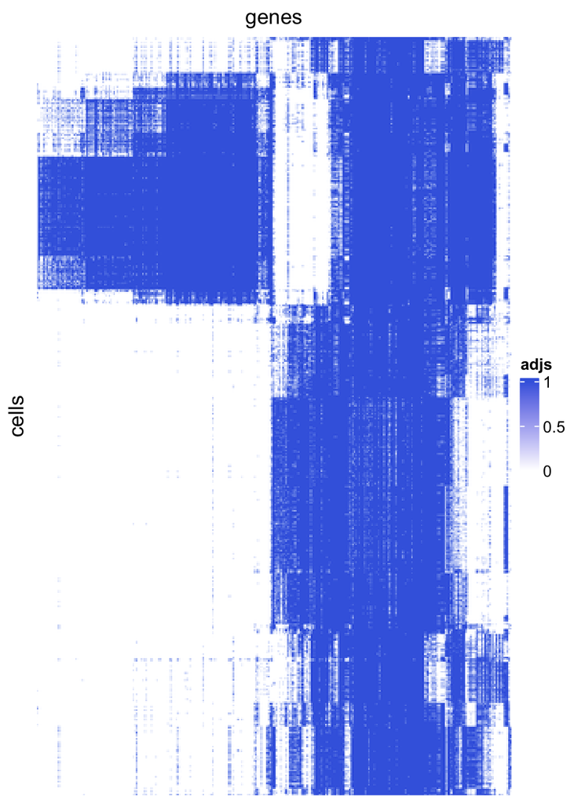

Figure 26

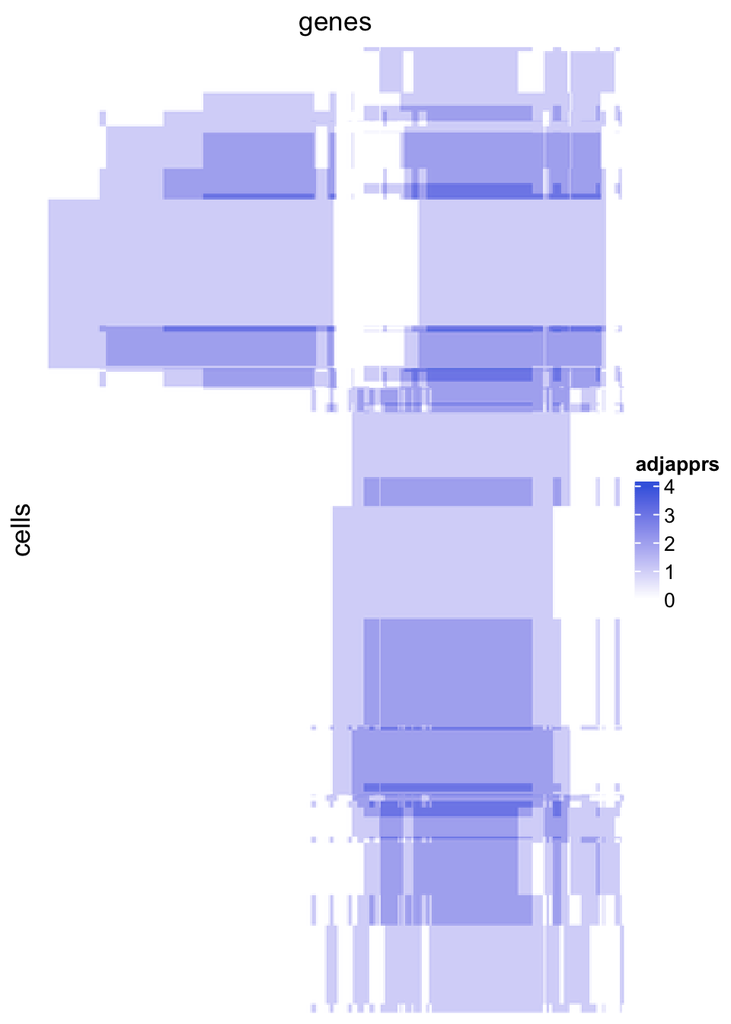

Figure 27

```r
ser <- seriate(adjappr4ser, method = "BEA_TSP")
myhm <- function(x, name = deparse(substitute(x)), col = colorRamp2(range(x), c("#ffffff", "RoyalBlue"))) {
  Heatmap(x, name = name, col = col, row_title = "cells", column_title = "genes",
      row_order = get_order(ser, 1), column_order = get_order(ser, 2),
      show_row_names = FALSE, show_column_names = FALSE, use_raster = TRUE)
}
myhm(adjs)
myhm(adjapprs)
```

Note how some biclusters are overlapping, as indicated by elements of `adjappr` having values above 1:

```r
table(adjappr)
```

```
adjappr
      0       1       2       3       4
6249200 4128178 2188054  244958    7275
```

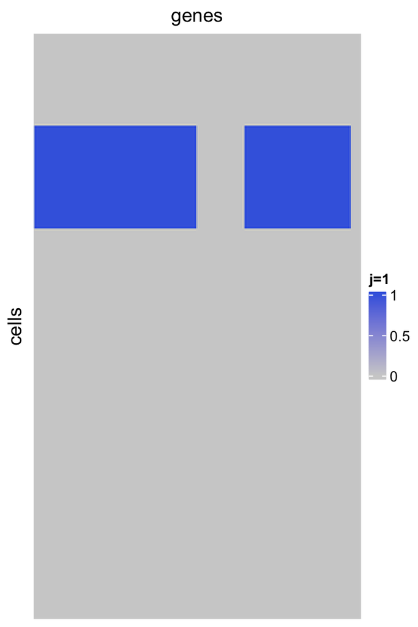

Figure 28

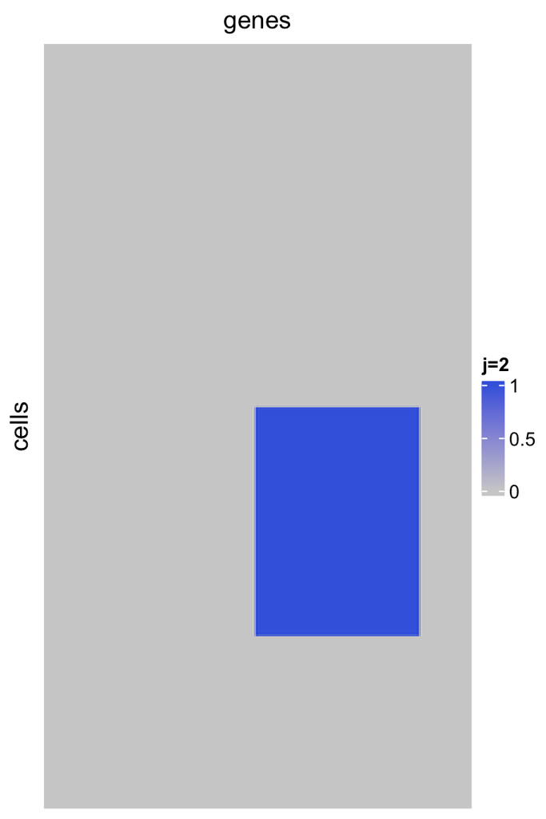

Figure 29

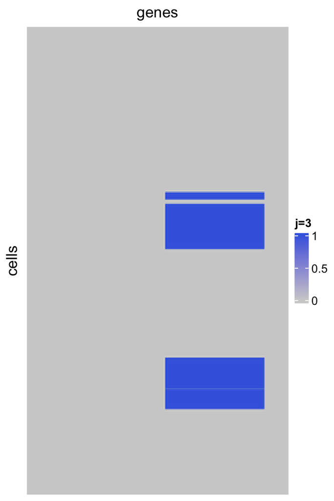

Figure 30

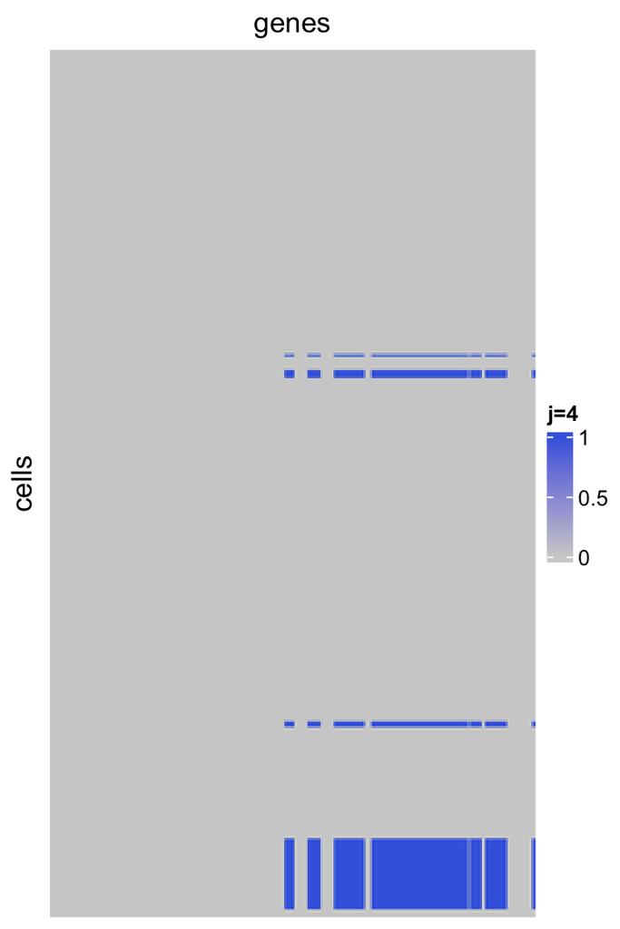

Figure 31

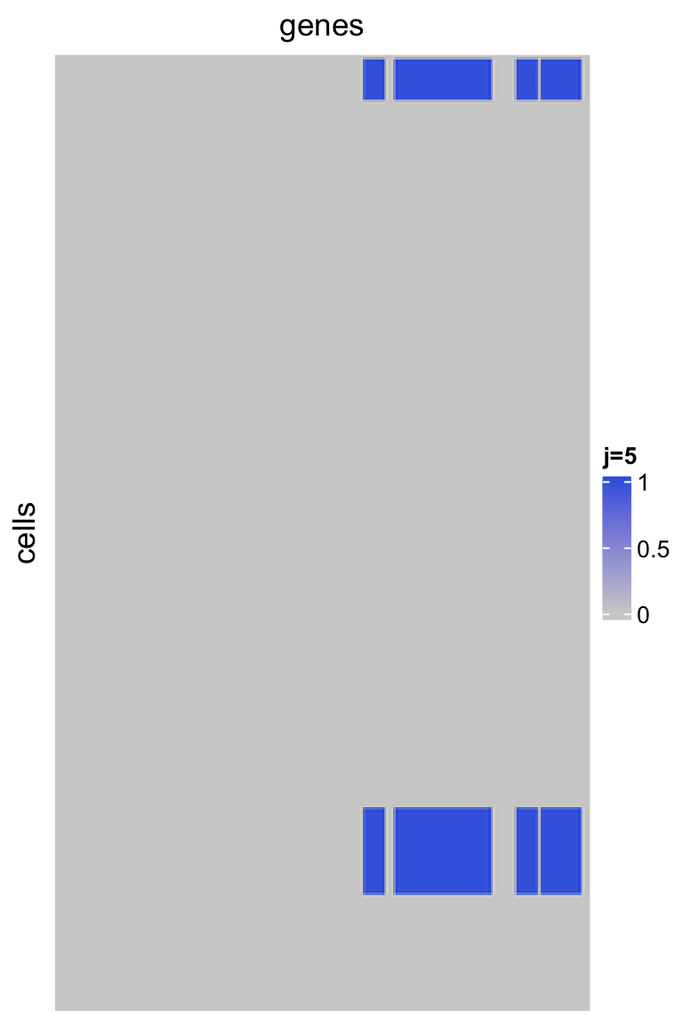

Figure 32

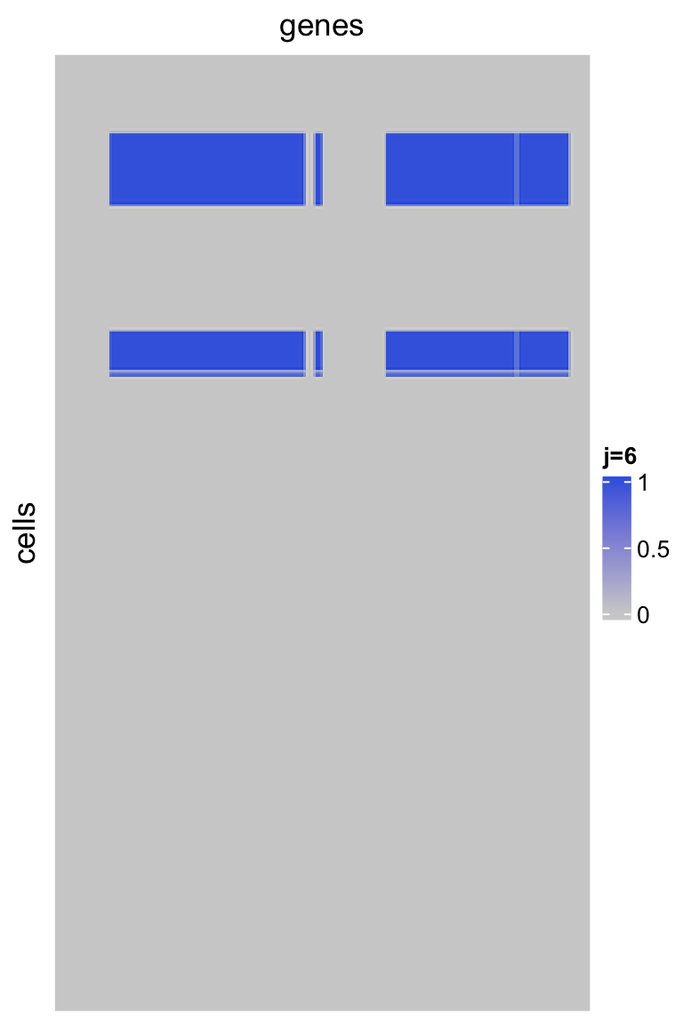

Figure 33

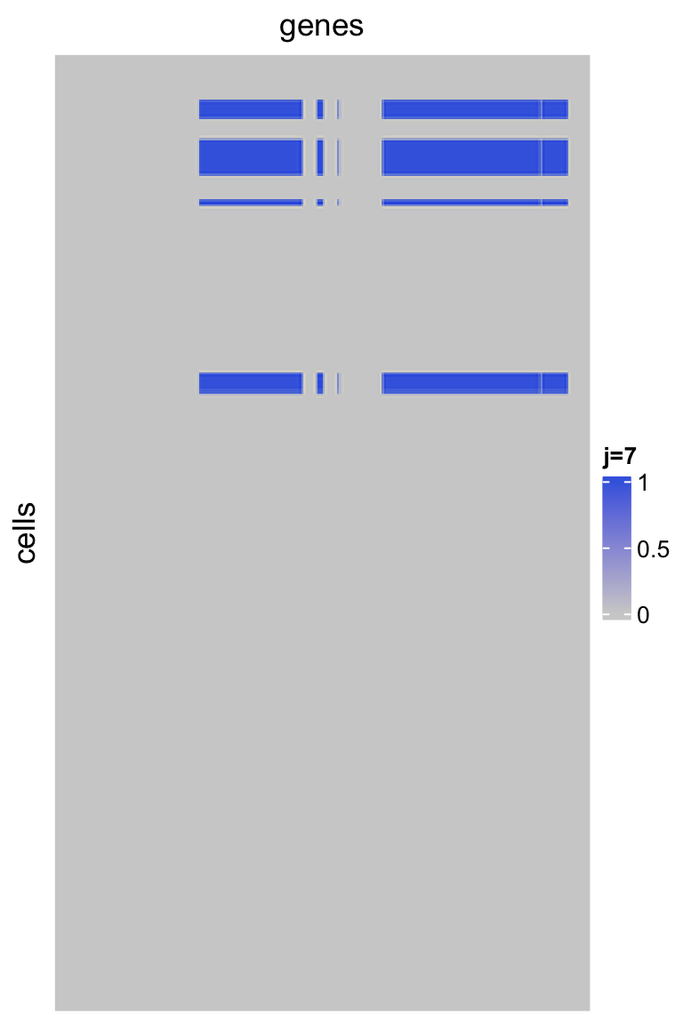

Figure 34

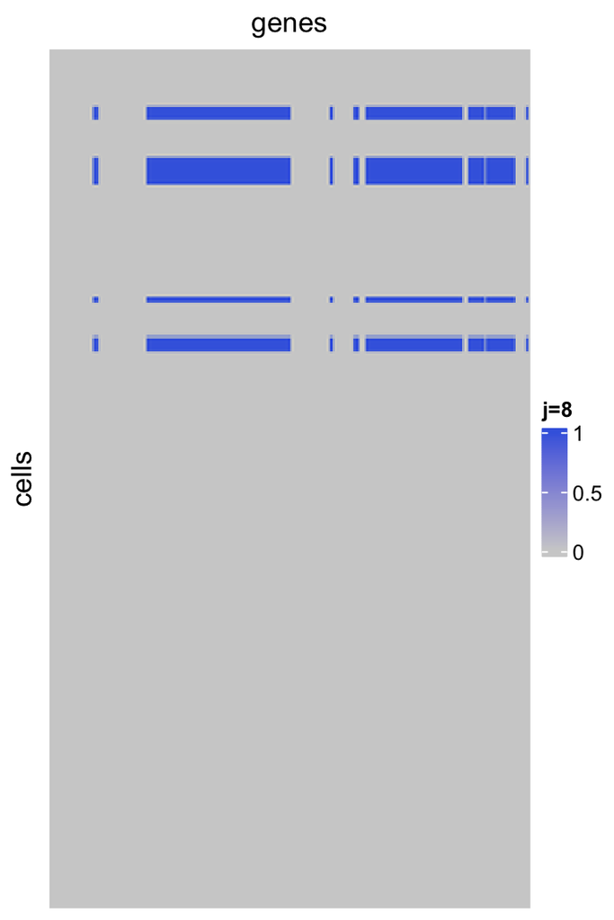

Figure 35

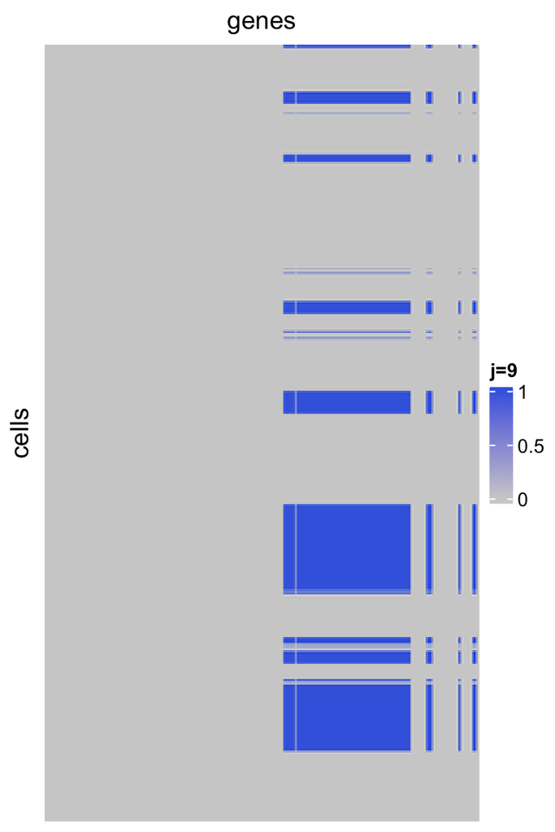

Figure 36

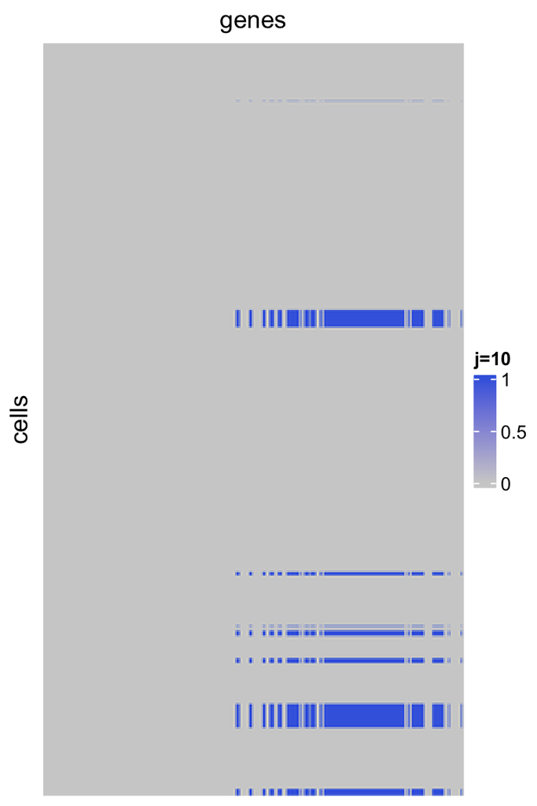

Figure 37

```r
for (j in seq_len(ncol(wd)))
  print(myhm(wd[csub, j, drop = FALSE]  %*% hd[j, , drop = FALSE],
             name = sprintf("j=%d", j),
             col = colorRamp2(c(0, 1), c("#d0d0d0", "RoyalBlue"))))
```

## References

Ahlmann-Eltze, C., and Wolfgang Huber. 2023. “Comparison of Transformations for Single-Cell RNA-Seq Data.” *Nature Methods*, February, 665–72. https://doi.org/10.1038/s41592-023-01814-1.

Ahlmann-Eltze, Constantin, and Wolfgang Huber. 2025. “Analysis of Multi-Condition Single-Cell Data with Latent Embedding Multivariate Regression.” *Nature Genetics*. https://doi.org/10.1038/s41588-024-01996-0.

Butler, Andrew, Paul Hoffman, Peter Smibert, Efthymia Papalexi, and Rahul Satija. 2018. “Integrating Single-Cell Transcriptomic Data Across Different Conditions, Technologies, and Species.” *Nature Biotechnology* 36 (5): 411–20. https://doi.org/10.1038/nbt.4096.

Haghverdi, Laleh, Aaron T L Lun, Michael D Morgan, and John C Marioni. 2018. “Batch Effects in Single-Cell RNA-Sequencing Data Are Corrected by Matching Mutual Nearest Neighbors.” *Nature Biotechnology* 36 (5): 421–27. https://doi.org/10.1038/nbt.4091.

Kang, Hyun Min, Meena Subramaniam, Sasha Targ, Michelle Nguyen, Lenka Maliskova, Elizabeth McCarthy, Eunice Wan, et al. 2018. “Multiplexed Droplet Single-Cell RNA-Sequencing Using Natural Genetic Variation.” *Nature Biotechnology* 36 (1): 89–94. https://doi.org/10.1038/nbt.4042.

Korsunsky, Ilya, Nghia Millard, Jean Fan, Kamil Slowikowski, Fan Zhang, Kevin Wei, Yuriy Baglaenko, Michael Brenner, Po-ru Loh, and Soumya Raychaudhuri. 2019. “Fast, Sensitive and Accurate Integration of Single-Cell Data with Harmony.” *Nature Methods* 16 (12): 1289–96. https://doi.org/10.1038/s41592-019-0619-0.

Luecken, Malte D., M. Büttner, K. Chaichoompu, A. Danese, M. Interlandi, M. F. Mueller, D. C. Strobl, et al. 2022. “Benchmarking Atlas-Level Data Integration in Single-Cell Genomics.” *Nature Methods* 19 (1): 41–50. https://doi.org/10.1038/s41592-021-01336-8.